# Correction Fiche 3 : Tests et régression linéaire

Septembre 2025

# Exercices

## Exercice 1

### Question 1

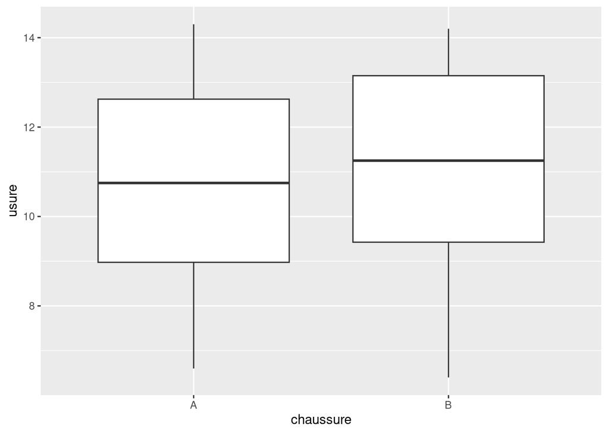

```r
usureA=c(13.2,8.2,10.9,14.3,10.7,6.6,9.5,10.8,8.8,13.3)
usureB=c(14,8.8,11.2,14.2,11.8,6.4,9.8,11.3,9.3,13.6)

data_usure=data.frame(usure=c(usureA,usureB),chaussure=rep(c("A","B"),each=10))

ggplot(data_usure,aes(x=chaussure,y=usure))+geom_boxplot()
```

```r
shapiro.test(usureA)
```

```
##
##  Shapiro-Wilk normality test
##
## data:  usureA
## W = 0.9624, p-value = 0.8129
```

```r
shapiro.test(usureB)
```

```
##
##  Shapiro-Wilk normality test
##
## data:  usureB
## W = 0.94815, p-value = 0.6467
```

Comme les échantillons sont de petite taille, on commence par faire un test de Shapiro-Wilk pour savoir si on peut faire une hypothèse de normalité. Les p-valeurs sont grandes dont on valide cette hypothèse, on va pouvoir faire un test de Student.

### Question 2

Modèle : Soit $X_i$ l’usure (i.e. le nombre de semaines avant la dégradation) de la chaussure portée par le $i$-ème sportif dans le groupe A Soit $Y_j$ l’usure (i.e. le nombre de semaines avant la dégradation) de la chaussure portée par le $j$-ème sportif dans le groupe B On suppose d’après la question 1 que $X_i \overset{iid}{\sim} \mathcal{N}({\mu_A,\sigma_A^2})$ et $Y_j \overset{iid}{\sim} \mathcal{N}({\mu_B,\sigma_B^2})$.

Hypothèses :

$H_0$ : Il n’est pas intéressant de changer de modèle, i.e. l’usure des semelles A est (inférieure ou) égale à celle des semelles B ($\mu_A =\mu_B$)

$H_1$ : Il est intéressant de changer de modèle, i.e les semelles A s’usent plus vite que les semelles B $\mu_A < \mu_B$.

```r
t.test(usureA, usureB,alternative="less")
```

```
##
##  Welch Two Sample t-test
##
## data:  usureA and usureB
## t = -0.36891, df = 17.987, p-value = 0.3583
## alternative hypothesis: true difference in means is less than 0
## 95 percent confidence interval:
##      -Inf 1.517281
## sample estimates:
## mean of x mean of y
##     10.63     11.04
```

La p-valeur est largement supérieure à $5\%$, on ne peut pas conclure que le nouveau modèle soit meilleur.

### Question 3

Si les semelles ont été portées successivement par les mêmes sportifs, les échantillons $X$ et $Y$ sont appariés.

Modèle : Soit $X_i$ l’usure (i.e. le nombre de semaines avant la dégradation) de la chaussure du modèle A portée par le $i$-ème sportif Soit $Y_i$ l’usure (i.e. le nombre de semaines avant la dégradation) de la chaussure du modèle B portée par le $i$-ème sportif On suppose toujours que $X_i \overset{iid}{\sim} \mathcal{N}({\mu_A,\sigma_A^2})$ et $Y_j \overset{iid}{\sim} \mathcal{N}({\mu_B,\sigma_B^2})$.

On va étudier la variable $D_i$ définie par $D_i=X_i-Y_i \overset{iid}{\sim}\mathcal{N}({\mu,\sigma^2})$

Hypothèses :

$H_0$ : Il n’est pas intéressant de changer de modèle, i.e. l’usure des semelles A est (inférieure ou) égale à celle des semelles B ($\mu=0$)

$H_1$ : Il est intéressant de changer de modèle, i.e les semelles A s’usent plus vite que les semelles B $\mu_A < 0$.

```r
t.test(usureA, usureB,alternative="less",paired=TRUE)
```

```
##
##  Paired t-test
##
## data:  usureA and usureB
## t = -3.3489, df = 9, p-value = 0.004269
## alternative hypothesis: true mean difference is less than 0
## 95 percent confidence interval:
##        -Inf -0.1855736
## sample estimates:
## mean difference
##           -0.41
```

```r
#ou bien
D=usureA-usureB
t.test(D,mu=0,alternative="less")
```

```
##
##  One Sample t-test
##
## data:  D
## t = -3.3489, df = 9, p-value = 0.004269
## alternative hypothesis: true mean is less than 0
## 95 percent confidence interval:
##        -Inf -0.1855736
## sample estimates:
## mean of x
##     -0.41
```

On trouve cette fois une p-valeur très faible, ce qui suggère que les semelles B s’usent moins vite que le modèle A.

Pourquoi trouve-t-on une conclusion si différente ?

Dans le premier cas, la statistique de test est :

$$T_1=\frac{\bar{X}-\bar{Y}}{\sqrt{\hat{s}_A^2/10+\hat{s}_B^2/10}}$$
et dans le 2e cas :

$$T_2=\frac{\bar{D}}{\sqrt{\hat{s}^2/10}}$$
Les numérateurs sont les mêmes car $\bar{D}=\bar{X}-\bar{Y}$ mais ce sont les variances empiriques qui sont très différentes, ce qui va modifier la statistique observée. On peut le vérifier :

```r
sqrt(var(usureA)/10+var(usureB)/10)
```

```
## [1] 1.111381
```

```r
sqrt(var(D)/10)
```

```
## [1] 0.1224291
```

## Exercice 2

On va effectuer un test de comparaison de moyennes sur des échantillons appariés (car les mesures sont faites sur les mêmes patients). On va donc étudier la différence entre les deux échantillons, que l’on commence par représenter :

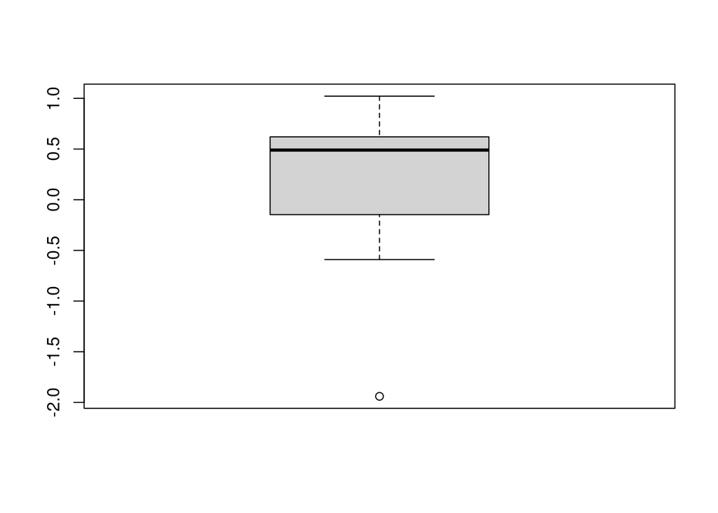

```r
x <- c(1.83,  0.50,  1.62,  2.48, 1.68, 1.88, 1.55,1.2, 0.7)
y <- c(0.878, 0.647, 0.598, 2.05, 1.06, 1.29, 1.06, 3.14, 1.29)
d=x-y
boxplot(d)
```

Cette différence n’a pas l’air centrée en 0. Pour savoir quel test effectuer, commençons par regarder si l’échantillon est gaussien (remarque : ici on n’a pas besoin que les deux échantillons soient gaussiens mais que la différence le soit.)

```r
shapiro.test(d)
```

```
##
##  Shapiro-Wilk normality test
##
## data:  d
## W = 0.82852, p-value = 0.04298
```

La p-valeur est inférieure à $5\%$, il n’est pas raisonnable de considérer que l’échantillon est gaussien. On va donc faire un test non paramétrique de Wilcoxon.

: $X_i$ la mesure de l’anxiété du patient $i$ avant le tranquilisant

$Y_i$ la mesure de l’anxiété du patient $i$ après le tranquilisant

On pose $D_i=X_i-Y_i$, on suppose les $D_i$ iid de loi inconnue et d’espérance $\mu$.

:

$H_0$ : le traitement n’est pas effice $\mu=0$

$H_1$ : traitement est efficace $\mu > 0$

```r
wilcox.test(x, y, paired = TRUE, alternative = "greater")
```

```
##
##  Wilcoxon signed rank exact test
##
## data:  x and y
## V = 30, p-value = 0.2129
## alternative hypothesis: true location shift is greater than 0
```

La p-valeur est largement supérieure à $5\%$, on ne peut pas considérer que le tranquilisant est efficace.

## Exercice 3 : Régression linaire simple (cas $p=1$)

### Question1

Importation du jeu de données :

```r
ozone <- read.table("ozone.txt", header = TRUE)
summary(ozone)
```

```
##      maxO3              T9             T12             T15
##  Min.   : 42.00   Min.   :11.30   Min.   :14.00   Min.   :14.90
##  1st Qu.: 70.75   1st Qu.:16.20   1st Qu.:18.60   1st Qu.:19.27
##  Median : 81.50   Median :17.80   Median :20.55   Median :22.05
##  Mean   : 90.30   Mean   :18.36   Mean   :21.53   Mean   :22.63
##  3rd Qu.:106.00   3rd Qu.:19.93   3rd Qu.:23.55   3rd Qu.:25.40
##  Max.   :166.00   Max.   :27.00   Max.   :33.50   Max.   :35.50
##       Ne9             Ne12            Ne15           Vx9
##  Min.   :0.000   Min.   :0.000   Min.   :0.00   Min.   :-7.8785
##  1st Qu.:3.000   1st Qu.:4.000   1st Qu.:3.00   1st Qu.:-3.2765
##  Median :6.000   Median :5.000   Median :5.00   Median :-0.8660
##  Mean   :4.929   Mean   :5.018   Mean   :4.83   Mean   :-1.2143
##  3rd Qu.:7.000   3rd Qu.:7.000   3rd Qu.:7.00   3rd Qu.: 0.6946
##  Max.   :8.000   Max.   :8.000   Max.   :8.00   Max.   : 5.1962
##       Vx12             Vx15            maxO3v           vent
##  Min.   :-7.878   Min.   :-9.000   Min.   : 42.00   Length:112
##  1st Qu.:-3.565   1st Qu.:-3.939   1st Qu.: 71.00   Class :character
##  Median :-1.879   Median :-1.550   Median : 82.50   Mode  :character
##  Mean   :-1.611   Mean   :-1.691   Mean   : 90.57
##  3rd Qu.: 0.000   3rd Qu.: 0.000   3rd Qu.:106.00
##  Max.   : 6.578   Max.   : 5.000   Max.   :166.00
##     pluie
##  Length:112
##  Class :character
##  Mode  :character
##
##
##
```

Ce sont donc les première et troisième colonnes que l’on va garder.

```r
ozone <- ozone[, c("maxO3", "T12")]
summary(ozone)
```

```
##      maxO3             T12
##  Min.   : 42.00   Min.   :14.00
##  1st Qu.: 70.75   1st Qu.:18.60
##  Median : 81.50   Median :20.55
##  Mean   : 90.30   Mean   :21.53
##  3rd Qu.:106.00   3rd Qu.:23.55
##  Max.   :166.00   Max.   :33.50
```

Représentation du nuage de points :

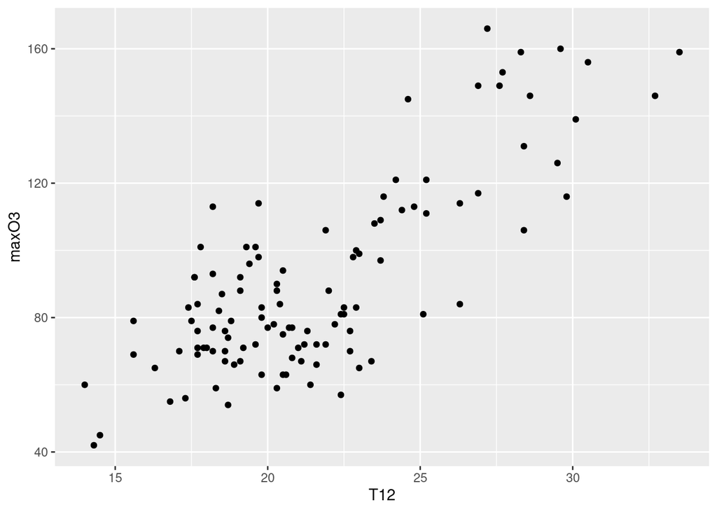

```r
library(ggplot2)
ggplot(ozone) + aes(x = T12, y = maxO3) + geom_point()
```

### Question 2

Un ajustement linéaire ne paraît pas absurde.

### Question 3

Calcul des coefficients de la droite de régression :

```r
reg <- lm(maxO3~T12, data = ozone)
summary(reg)
```

```
##
## Call:
## lm(formula = maxO3 ~ T12, data = ozone)
##
## Residuals:
##     Min      1Q  Median      3Q     Max
## -38.079 -12.735   0.257  11.003  44.671
##
## Coefficients:
##             Estimate Std. Error t value Pr(>|t|)
## (Intercept) -27.4196     9.0335  -3.035    0.003 **
## T12           5.4687     0.4125  13.258   <2e-16 ***
## ---
## Signif. codes:  0 '***' 0.001 '**' 0.01 '*' 0.05 '.' 0.1 ' ' 1
##
## Residual standard error: 17.57 on 110 degrees of freedom
## Multiple R-squared:  0.6151, Adjusted R-squared:  0.6116
## F-statistic: 175.8 on 1 and 110 DF,  p-value: < 2.2e-16
```

On voit donc que $\hat\beta_0\approx-27.4$ et $\hat\beta_1\approx 5.5$.

### Question 4

Le résultat de l’appel à la fonction **lm** ci-dessus est une liste dont voici les éléments

```r
names(reg)
```

```
##  [1] "coefficients"  "residuals"     "effects"       "rank"
##  [5] "fitted.values" "assign"        "qr"            "df.residual"
##  [9] "xlevels"       "call"          "terms"         "model"
```

### Question 5

On obtient donc les coefficients très facilement :

```r
beta <- reg$coefficients
beta
```

```
## (Intercept)         T12
##  -27.419636    5.468685
```

L’écart-type résiduel (ou **Residual Standard Error**) est défini de façon générale par
$$\hat\sigma=\sqrt{\frac{1}{n-p}\sum_{i=1}^n\hat\varepsilon_i^2}=\sqrt{\frac{1}{n-p}\sum_{i=1}^n(y_i-\hat
y_i)^2}=\sqrt{\frac{1}{n-p}\sum_{i=1}^n(y_i-\hat\beta_0-\hat\beta_1
x_i)^2}.$$
Dans notre cas ceci donne :

```r
SCR <- sum((ozone$maxO3 - (beta[1] + beta[2]*ozone$T12))^2)
n <- nrow(ozone)
sigmahat <- sqrt(SCR/(n - 2))
sigmahat
```

```
## [1] 17.56749
```

on retrouve bien la **Residual Standard Error** du résumé ci-dessus.

### Question 6

Représentation de la droite de régression et du centre de gravité :

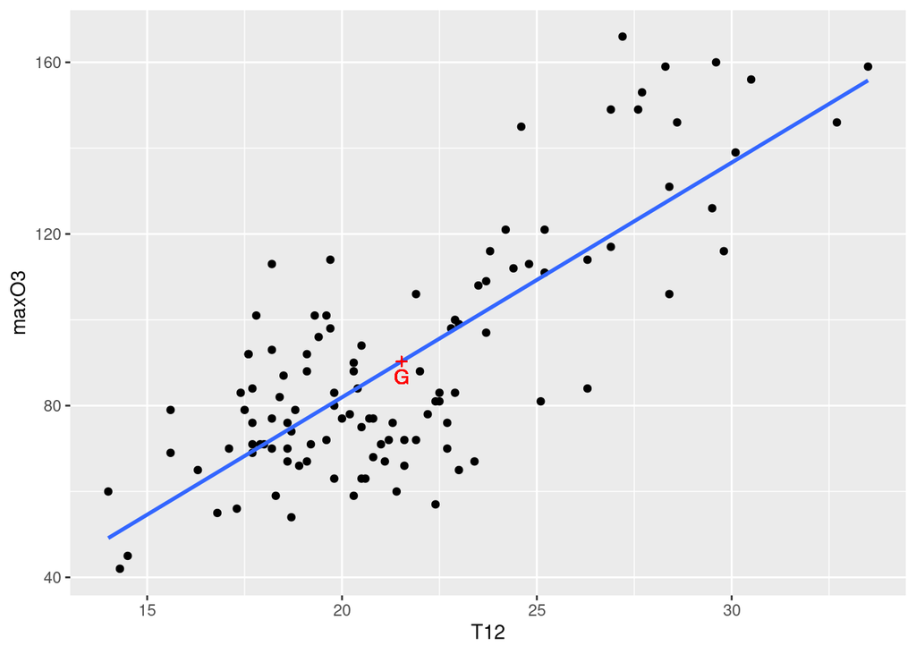

```r
plot1 <- ggplot(ozone) + aes(x = T12, y = maxO3) + geom_point() + geom_smooth(method = 'lm', se = F)
plot1 <- plot1 + geom_point(x = mean(ozone$T12), y = mean(ozone$maxO3), colour = "red", shape = 3)
plot1 <- plot1 + geom_text(x = mean(ozone$T12), y = mean(ozone$maxO3), label = "G", colour = "red", vjust = 1.5)
plot1
```

### Question 7

Représentation des résidus :

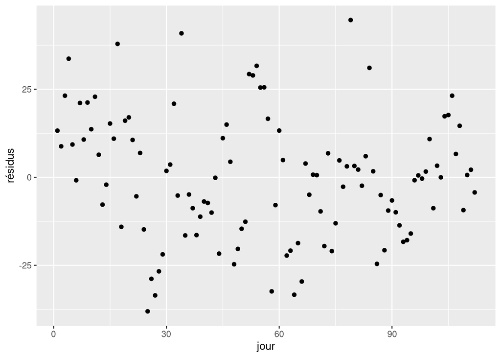

```r
n <- nrow(ozone)
data_reg=data.frame(obs=1:n,residus=residuals(reg))
ggplot(data_reg,aes(x=obs,y=residus))+geom_point() + xlab("jour") + ylab("résidus")
```

### Question 8

Il est plus judicieux de regarder les résidus studentisés. En effet, si l’hypothèse d’erreurs gaussiennes centrées homoscédastiques est vérifiée, on sait que ceux-ci sont distribués selon une loi de Student à $n-3=109$ degrés de liberté :

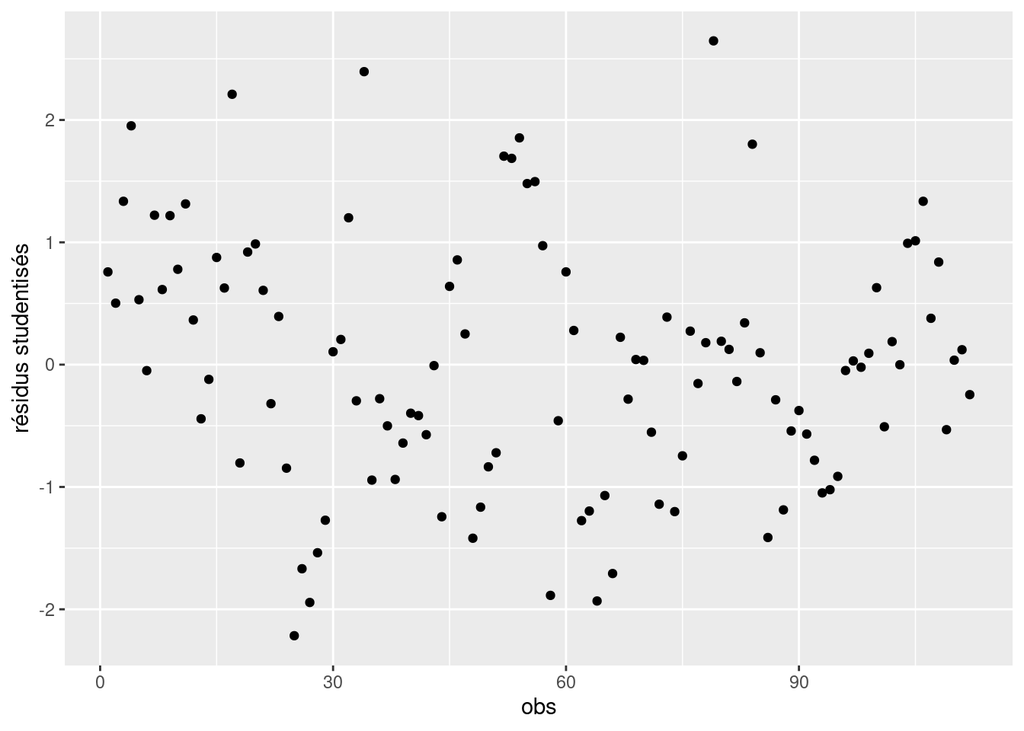

```r
n <- nrow(ozone)
data_reg=data.frame(obs=1:n,residus=rstudent(reg))
ggplot(data_reg,aes(x=obs,y=residus))+geom_point() + ylab("résidus studentisés")
```

On constate que 4 valeurs sur 112 sont à l’extérieur de l’intervalle de confiance à 95%, ce qui est raisonnable.

### Question 9

Si on superpose la densité d’une loi de Student à $n-3=109$ degrés de liberté et un estimateur de la densité, on constate également une bonne adéquation :

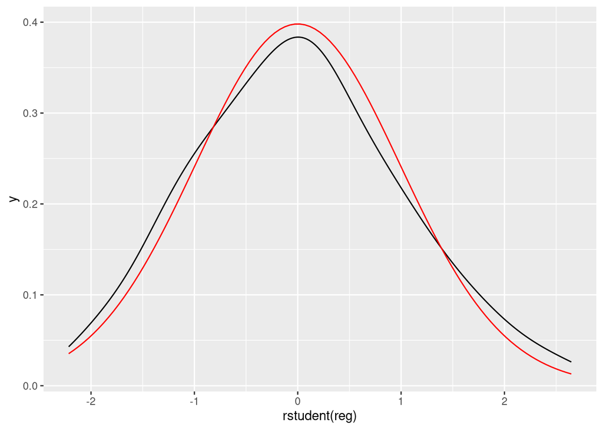

```r
plot2 <- ggplot(data.frame(rstudent(reg)), aes(x = rstudent(reg)))
plot2 <- plot2 + geom_line(stat = "density") + stat_function(fun = dt, args = list(df = 109), col = "red")
plot2
```

### Question 10

La valeur prédite est tout simplement :

```r
maxO3p <- beta[1] + beta[2]*25
maxO3p
```

```
## (Intercept)
##    109.2975
```

### Question 11

A l’aide de la fonction **predict** :

```r
demain <- data.frame(25)
colnames(demain) <- "T12"
predict(reg, newdata = demain)
```

```
##        1
## 109.2975
```

Si on veut, en outre, un intervalle de prédiction à 95% :

```r
predict(reg, newdata = demain, interval = "prediction")
```

```
##        fit      lwr      upr
## 1 109.2975 74.21269 144.3823
```

## Exercice 4 : Régression linéaire multiple (cas $p>1$)

### Question 1

Importation du jeu de données :

```r
ozone <- read.table("ozone.txt", header = TRUE)
summary(ozone)
```

```
##      maxO3              T9             T12             T15
##  Min.   : 42.00   Min.   :11.30   Min.   :14.00   Min.   :14.90
##  1st Qu.: 70.75   1st Qu.:16.20   1st Qu.:18.60   1st Qu.:19.27
##  Median : 81.50   Median :17.80   Median :20.55   Median :22.05
##  Mean   : 90.30   Mean   :18.36   Mean   :21.53   Mean   :22.63
##  3rd Qu.:106.00   3rd Qu.:19.93   3rd Qu.:23.55   3rd Qu.:25.40
##  Max.   :166.00   Max.   :27.00   Max.   :33.50   Max.   :35.50
##       Ne9             Ne12            Ne15           Vx9
##  Min.   :0.000   Min.   :0.000   Min.   :0.00   Min.   :-7.8785
##  1st Qu.:3.000   1st Qu.:4.000   1st Qu.:3.00   1st Qu.:-3.2765
##  Median :6.000   Median :5.000   Median :5.00   Median :-0.8660
##  Mean   :4.929   Mean   :5.018   Mean   :4.83   Mean   :-1.2143
##  3rd Qu.:7.000   3rd Qu.:7.000   3rd Qu.:7.00   3rd Qu.: 0.6946
##  Max.   :8.000   Max.   :8.000   Max.   :8.00   Max.   : 5.1962
##       Vx12             Vx15            maxO3v           vent
##  Min.   :-7.878   Min.   :-9.000   Min.   : 42.00   Length:112
##  1st Qu.:-3.565   1st Qu.:-3.939   1st Qu.: 71.00   Class :character
##  Median :-1.879   Median :-1.550   Median : 82.50   Mode  :character
##  Mean   :-1.611   Mean   :-1.691   Mean   : 90.57
##  3rd Qu.: 0.000   3rd Qu.: 0.000   3rd Qu.:106.00
##  Max.   : 6.578   Max.   : 5.000   Max.   :166.00
##     pluie
##  Length:112
##  Class :character
##  Mode  :character
##
##
##
```

```r
ozone <- ozone[, 1:11]
```

### Question 2

Résumé du data-frame :

```r
summary(ozone)
```

```
##      maxO3              T9             T12             T15
##  Min.   : 42.00   Min.   :11.30   Min.   :14.00   Min.   :14.90
##  1st Qu.: 70.75   1st Qu.:16.20   1st Qu.:18.60   1st Qu.:19.27
##  Median : 81.50   Median :17.80   Median :20.55   Median :22.05
##  Mean   : 90.30   Mean   :18.36   Mean   :21.53   Mean   :22.63
##  3rd Qu.:106.00   3rd Qu.:19.93   3rd Qu.:23.55   3rd Qu.:25.40
##  Max.   :166.00   Max.   :27.00   Max.   :33.50   Max.   :35.50
##       Ne9             Ne12            Ne15           Vx9
##  Min.   :0.000   Min.   :0.000   Min.   :0.00   Min.   :-7.8785
##  1st Qu.:3.000   1st Qu.:4.000   1st Qu.:3.00   1st Qu.:-3.2765
##  Median :6.000   Median :5.000   Median :5.00   Median :-0.8660
##  Mean   :4.929   Mean   :5.018   Mean   :4.83   Mean   :-1.2143
##  3rd Qu.:7.000   3rd Qu.:7.000   3rd Qu.:7.00   3rd Qu.: 0.6946
##  Max.   :8.000   Max.   :8.000   Max.   :8.00   Max.   : 5.1962
##       Vx12             Vx15            maxO3v
##  Min.   :-7.878   Min.   :-9.000   Min.   : 42.00
##  1st Qu.:-3.565   1st Qu.:-3.939   1st Qu.: 71.00
##  Median :-1.879   Median :-1.550   Median : 82.50
##  Mean   :-1.611   Mean   :-1.691   Mean   : 90.57
##  3rd Qu.: 0.000   3rd Qu.: 0.000   3rd Qu.:106.00
##  Max.   : 6.578   Max.   : 5.000   Max.   :166.00
```

### Question 3

Régression linéaire

```r
reg <- lm(maxO3~., data = ozone)
```

### Question 4

Résumé du modèle linéaire :

```r
summary(reg)
```

```
##
## Call:
## lm(formula = maxO3 ~ ., data = ozone)
##
## Residuals:
##     Min      1Q  Median      3Q     Max
## -53.566  -8.727  -0.403   7.599  39.458
##
## Coefficients:
##             Estimate Std. Error t value Pr(>|t|)
## (Intercept) 12.24442   13.47190   0.909   0.3656
## T9          -0.01901    1.12515  -0.017   0.9866
## T12          2.22115    1.43294   1.550   0.1243
## T15          0.55853    1.14464   0.488   0.6266
## Ne9         -2.18909    0.93824  -2.333   0.0216 *
## Ne12        -0.42102    1.36766  -0.308   0.7588
## Ne15         0.18373    1.00279   0.183   0.8550
## Vx9          0.94791    0.91228   1.039   0.3013
## Vx12         0.03120    1.05523   0.030   0.9765
## Vx15         0.41859    0.91568   0.457   0.6486
## maxO3v       0.35198    0.06289   5.597 1.88e-07 ***
## ---
## Signif. codes:  0 '***' 0.001 '**' 0.01 '*' 0.05 '.' 0.1 ' ' 1
##
## Residual standard error: 14.36 on 101 degrees of freedom
## Multiple R-squared:  0.7638, Adjusted R-squared:  0.7405
## F-statistic: 32.67 on 10 and 101 DF,  p-value: < 2.2e-16
```

Testées une par une, les seules variables significatives au niveau 5% sont **maxO3v** et **Ne9**, mais la régression étant multiple et les variables explicatives non orthogonales, il est délicat d’utiliser ces tests. En effet, le test sur un coefficient revient à tester la significativité d’une variable alors que les autres sont dans le modèle. Autrement dit, cela revient à tester que la variable n’apporte pas d’information supplémentaire sachant que toutes les autres variables sont dans le modèle. Il est donc important et plus pertinent d’appliquer des procédures de choix de modèle comme ci-dessous.

Par ailleurs, la **F-statistic** correspond à la statistique du test de Fisher global vu en cours, laquelle revient à tester s’il y a, en plus de la constante, au moins une variable explicative significative parmi les 10 variables proposées. On peut l’exprimer à partir du coefficient de détermination $R^2$ :
$$F=\frac{n-p}{p-1}\times\frac{R^2}{1-R^2}.$$
Le $R^2$ est le **Multiple R-squared** du résumé, qui vaut $0.764$ d’où

```r
F <- (112 - 11)/(11 - 1)*0.7638/(1 - 0.7638)
F
```

```
## [1] 32.66037
```

On retrouve bien la **F-statistic** du résumé.

### Question 5

Choix de variable par le critère d’information bayésien (BIC) :

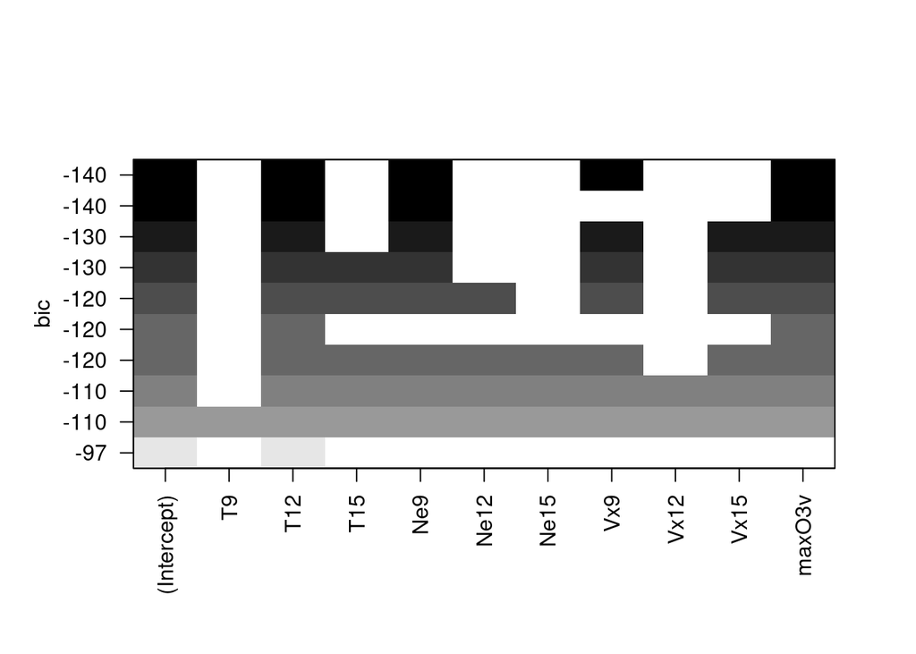

```r
library(leaps)
choix <- regsubsets(maxO3~., data = ozone, nbest = 1, nvmax = 11)
plot(choix, scale="bic")
```

Le critère est optimisé pour la ligne en haut du graphique. Nous conservons donc, pour le critère BIC, le modèle à 4 variables (en plus de la constante) : **T12**, **Ne9**, **Vx9** et **maxO3v**.

### Question 6

Nous définissons ainsi un nouveau modèle avec ces variables :

```r
regbis <- lm(maxO3~T12 + Ne9 + Vx9 + maxO3v, data = ozone)
summary(regbis)
```

```
##
## Call:
## lm(formula = maxO3 ~ T12 + Ne9 + Vx9 + maxO3v, data = ozone)
##
## Residuals:
##     Min      1Q  Median      3Q     Max
## -52.396  -8.377  -1.086   7.951  40.933
##
## Coefficients:
##             Estimate Std. Error t value Pr(>|t|)
## (Intercept) 12.63131   11.00088   1.148 0.253443
## T12          2.76409    0.47450   5.825 6.07e-08 ***
## Ne9         -2.51540    0.67585  -3.722 0.000317 ***
## Vx9          1.29286    0.60218   2.147 0.034055 *
## maxO3v       0.35483    0.05789   6.130 1.50e-08 ***
## ---
## Signif. codes:  0 '***' 0.001 '**' 0.01 '*' 0.05 '.' 0.1 ' ' 1
##
## Residual standard error: 14 on 107 degrees of freedom
## Multiple R-squared:  0.7622, Adjusted R-squared:  0.7533
## F-statistic: 85.75 on 4 and 107 DF,  p-value: < 2.2e-16
```

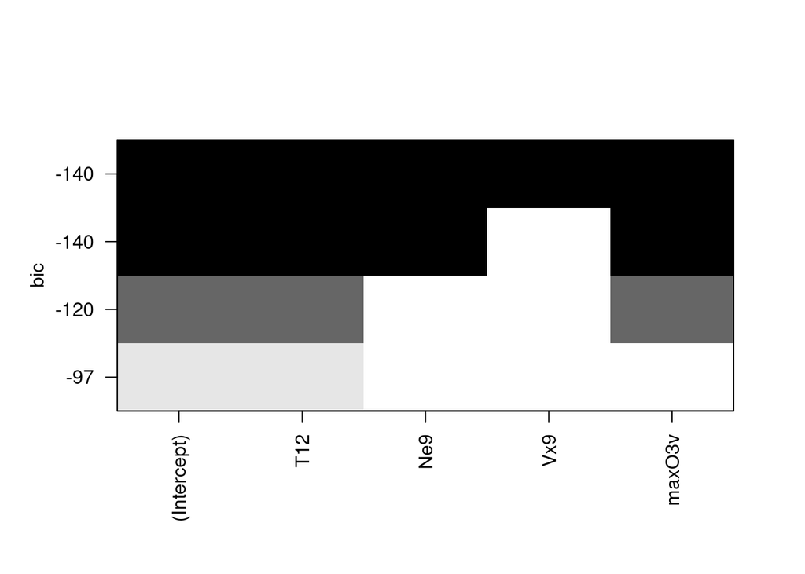

```r
library(leaps)
choixbis <- regsubsets(maxO3~T12 + Ne9 + Vx9 + maxO3v, data = ozone, nbest = 1, nvmax = 5)
plot(choixbis, scale = "bic")
```

## Exercice 5

### Question 1

```r
ozone <- read.table("ozone.txt",header=TRUE)
summary(ozone)
```

```
##      maxO3              T9             T12             T15
##  Min.   : 42.00   Min.   :11.30   Min.   :14.00   Min.   :14.90
##  1st Qu.: 70.75   1st Qu.:16.20   1st Qu.:18.60   1st Qu.:19.27
##  Median : 81.50   Median :17.80   Median :20.55   Median :22.05
##  Mean   : 90.30   Mean   :18.36   Mean   :21.53   Mean   :22.63
##  3rd Qu.:106.00   3rd Qu.:19.93   3rd Qu.:23.55   3rd Qu.:25.40
##  Max.   :166.00   Max.   :27.00   Max.   :33.50   Max.   :35.50
##       Ne9             Ne12            Ne15           Vx9
##  Min.   :0.000   Min.   :0.000   Min.   :0.00   Min.   :-7.8785
##  1st Qu.:3.000   1st Qu.:4.000   1st Qu.:3.00   1st Qu.:-3.2765
##  Median :6.000   Median :5.000   Median :5.00   Median :-0.8660
##  Mean   :4.929   Mean   :5.018   Mean   :4.83   Mean   :-1.2143
##  3rd Qu.:7.000   3rd Qu.:7.000   3rd Qu.:7.00   3rd Qu.: 0.6946
##  Max.   :8.000   Max.   :8.000   Max.   :8.00   Max.   : 5.1962
##       Vx12             Vx15            maxO3v           vent
##  Min.   :-7.878   Min.   :-9.000   Min.   : 42.00   Length:112
##  1st Qu.:-3.565   1st Qu.:-3.939   1st Qu.: 71.00   Class :character
##  Median :-1.879   Median :-1.550   Median : 82.50   Mode  :character
##  Mean   :-1.611   Mean   :-1.691   Mean   : 90.57
##  3rd Qu.: 0.000   3rd Qu.: 0.000   3rd Qu.:106.00
##  Max.   : 6.578   Max.   : 5.000   Max.   :166.00
##     pluie
##  Length:112
##  Class :character
##  Mode  :character
##
##
##
```

```r
ozone <- ozone[,c("maxO3","vent")]
```

### Question 2

```r
summary(ozone)
```

```
##      maxO3            vent
##  Min.   : 42.00   Length:112
##  1st Qu.: 70.75   Class :character
##  Median : 81.50   Mode  :character
##  Mean   : 90.30
##  3rd Qu.:106.00
##  Max.   :166.00
```

On constate que c’est le vent d’ouest qui est dominant.

### Question 3

Construction des boxplots :

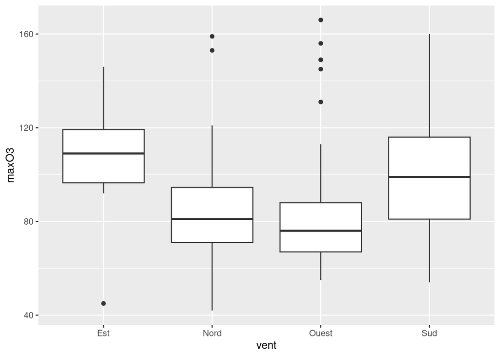

```r
library(ggplot2)
ggplot(ozone)+aes(x=vent,y=maxO3)+geom_boxplot()
```

La distribution du max de l’ozone diffère selon la direction du vent : par exemple, le niveau d’ozone est sensiblement différent selon que le vent est d’est ou d’ouest. Il semble donc en effet y avoir un effet vent, c’est ce que nous allons vérifier dans la suite.

### Question 4

Pour analyser la significativité du facteur vent, on utilise à nouveau la fonction **lm** dans un premier temps, puis la fonction **anova**.

```r
modele <- lm(maxO3~vent,data=ozone)
summary(modele)
```

```
##
## Call:
## lm(formula = maxO3 ~ vent, data = ozone)
##
## Residuals:
##     Min      1Q  Median      3Q     Max
## -60.600 -16.807  -7.365  11.478  81.300
##
## Coefficients:
##             Estimate Std. Error t value Pr(>|t|)
## (Intercept)  105.600      8.639  12.223   <2e-16 ***
## ventNord     -19.471      9.935  -1.960   0.0526 .
## ventOuest    -20.900      9.464  -2.208   0.0293 *
## ventSud       -3.076     10.496  -0.293   0.7700
## ---
## Signif. codes:  0 '***' 0.001 '**' 0.01 '*' 0.05 '.' 0.1 ' ' 1
##
## Residual standard error: 27.32 on 108 degrees of freedom
## Multiple R-squared:  0.08602,    Adjusted R-squared:  0.06063
## F-statistic: 3.388 on 3 and 108 DF,  p-value: 0.02074
```

```r
anova(modele)
```

```
## Analysis of Variance Table
##
## Response: maxO3
##            Df Sum Sq Mean Sq F value  Pr(>F)
## vent        3   7586 2528.69  3.3881 0.02074 *
## Residuals 108  80606  746.35
## ---
## Signif. codes:  0 '***' 0.001 '**' 0.01 '*' 0.05 '.' 0.1 ' ' 1
```

- La probabilité critique associée au test de Fisher vaut environ 0.02, donc au niveau de risque de 5%, on rejette $H_0$. Autrement dit, il existe au moins une modalité de la variable vent (i.e. une direction du vent) qui est significative pour expliquer le max de l’ozone.
- Comme d’habitude, ce modèle suppose les $\varepsilon_{ij}$ gaussiens indépendants centrés et de même variance.
6. Pour analyser les résidus studentisés, comme en régression linéaire, on fait appel à la fonction **rstudent**.
   - Représentation des résidus studentisés :

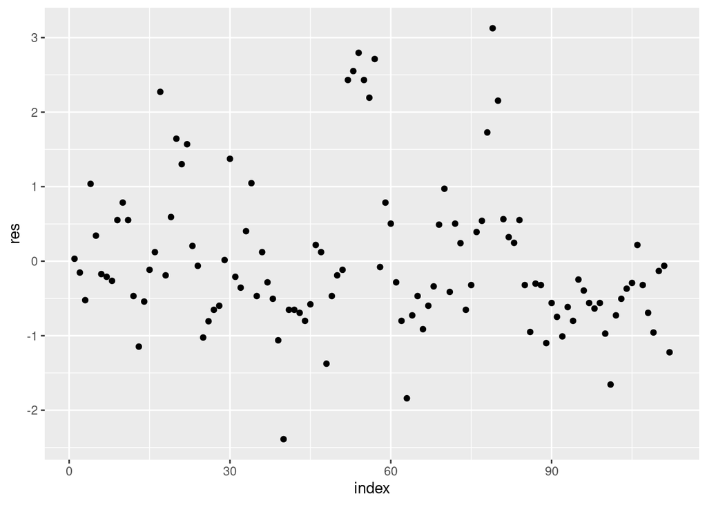

```r
n <- nrow(ozone)
df <- data.frame(index=1:n,res=rstudent(modele))
ggplot(df)+aes(x=index,y=res)+geom_point()
```

- Représentation des résidus studentisés en fonction du vent :

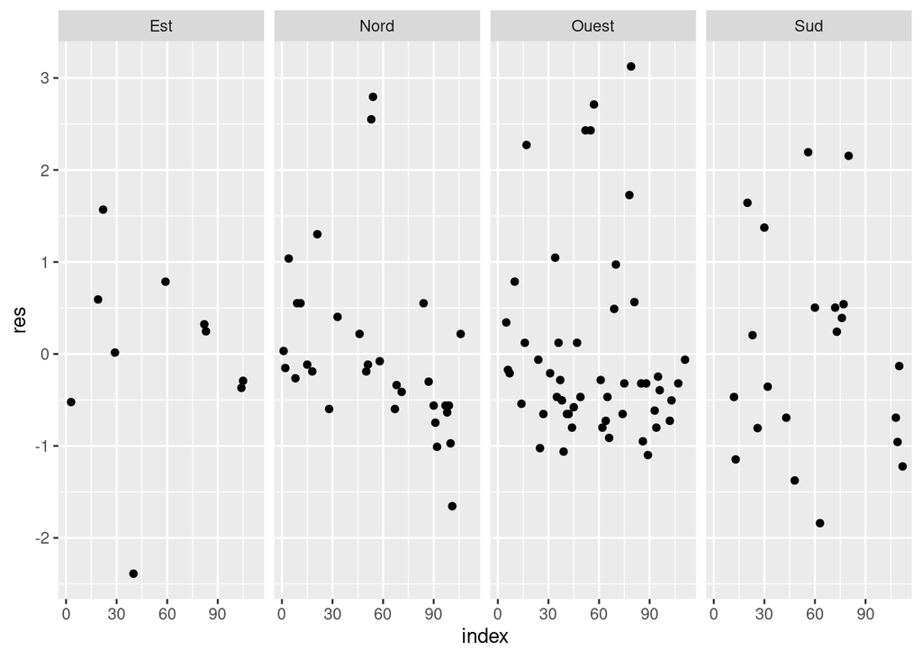

```r
df2 <- data.frame(df,vent=ozone$vent)
ggplot(df2)+aes(x=index,y=res)+geom_point()+facet_grid(.~vent)
```

- Boîtes à moustaches :

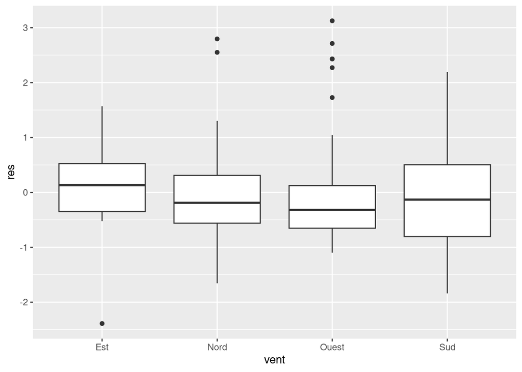

```r
library(ggplot2)
ggplot(df2)+aes(x=vent,y=res)+geom_boxplot()
```

7. On revient aux résultats de la fonction **lm**.
   - Résumé :

```r
summary(modele)
```

```
##
## Call:
## lm(formula = maxO3 ~ vent, data = ozone)
##
## Residuals:
##     Min      1Q  Median      3Q     Max
## -60.600 -16.807  -7.365  11.478  81.300
##
## Coefficients:
##             Estimate Std. Error t value Pr(>|t|)
## (Intercept)  105.600      8.639  12.223   <2e-16 ***
## ventNord     -19.471      9.935  -1.960   0.0526 .
## ventOuest    -20.900      9.464  -2.208   0.0293 *
## ventSud       -3.076     10.496  -0.293   0.7700
## ---
## Signif. codes:  0 '***' 0.001 '**' 0.01 '*' 0.05 '.' 0.1 ' ' 1
##
## Residual standard error: 27.32 on 108 degrees of freedom
## Multiple R-squared:  0.08602,    Adjusted R-squared:  0.06063
## F-statistic: 3.388 on 3 and 108 DF,  p-value: 0.02074
```

C’est le vent d’est qui est pris comme référence car c’est le premier par ordre alphabétique.

- Le modèle s’écrit donc pour le vent d’est :
  $$y_{E,j}=105.6+\varepsilon_{E,j}$$
  Pour le vent de nord, on obtient :
  $$y_{N,j}=105.6-19.471+\varepsilon_{N,j}=86.129+\varepsilon_{N,j}$$
  Et ainsi de suite.
- Avec une p-value de 0.77, le vent de sud est comparable au vent d’est du point de vue de l’effet sur l’ozone. Ceci se voyait d’ailleurs sur le boxplot initial :

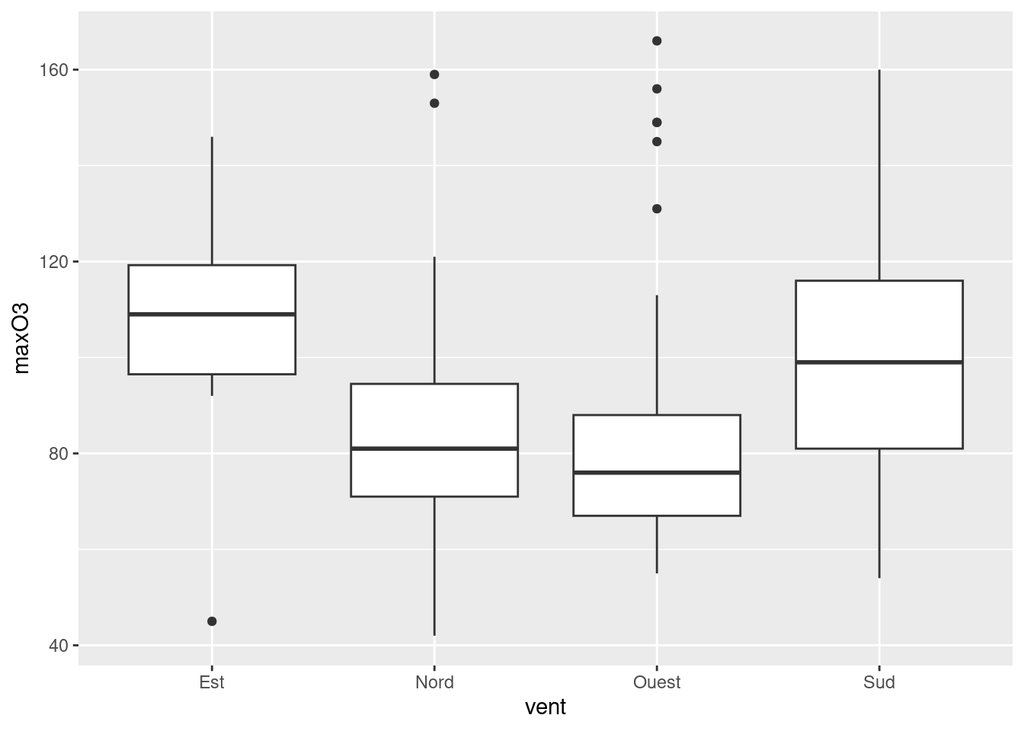

```r
ggplot(ozone)+aes(x=vent,y=maxO3)+geom_boxplot()
```

8. Résumons le nouveau modèle :

```r
modele2 <- lm(maxO3~vent,data=ozone)
summary(modele2)
```

```
##
## Call:
## lm(formula = maxO3 ~ vent, data = ozone)
##
## Residuals:
##     Min      1Q  Median      3Q     Max
## -60.600 -16.807  -7.365  11.478  81.300
##
## Coefficients:
##             Estimate Std. Error t value Pr(>|t|)
## (Intercept)  105.600      8.639  12.223   <2e-16 ***
## ventNord     -19.471      9.935  -1.960   0.0526 .
## ventOuest    -20.900      9.464  -2.208   0.0293 *
## ventSud       -3.076     10.496  -0.293   0.7700
## ---
## Signif. codes:  0 '***' 0.001 '**' 0.01 '*' 0.05 '.' 0.1 ' ' 1
##
## Residual standard error: 27.32 on 108 degrees of freedom
## Multiple R-squared:  0.08602,    Adjusted R-squared:  0.06063
## F-statistic: 3.388 on 3 and 108 DF,  p-value: 0.02074
```